# **FordGoBike-Trip Data Presentation**

## by (Subrat Kumar Singh)

## **Investigation Overview**

This presentation explores the Ford GoBike dataset to understand how trip duration varies with features such as age, gender, user type, start station, and end station. The analysis showed that most rides were short commuting trips, Subscribers dominated the platform usage, and Customers generally took longer rides across different demographic groups.

## **Dataset Overview**

The dataset contains bike trip information for February 2019, containing 183,412 trip records including 16 features, in which some feature we will explore includes trip duration, stations, gender, user type, birth year, and Main Feature of Interest is duration_sec

### **Wrangling**

### **Distribution of Trip Duration**

Key Insight: The trip duration distribution is highly right-skewed, where most bike rides are concentrated at shorter durations.

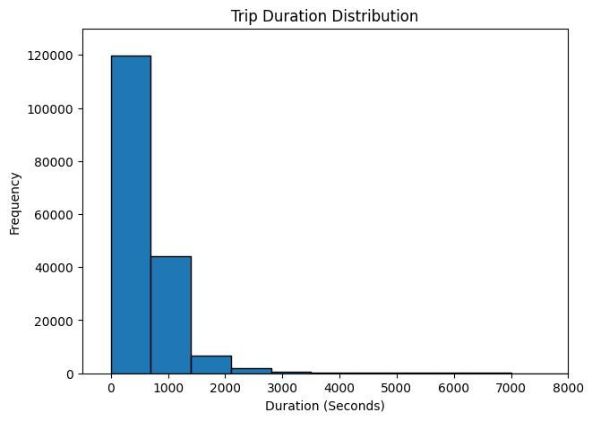

### **User Type Distribution**

[figure not shown]

### **Age Distribution**

Key Insight: - Most riders are from 20-40 age groups, and young riders shows the more number of rides

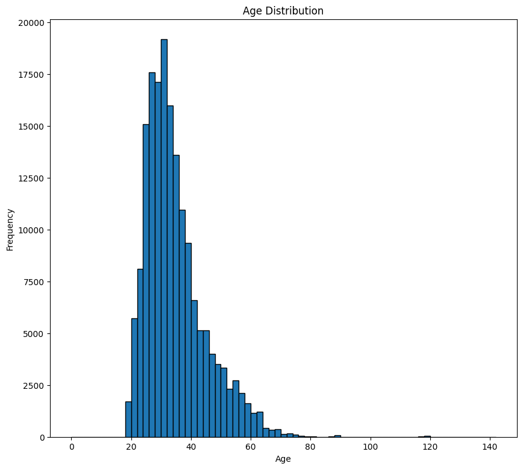

### **Age vs Trip Duration**

Key Insight: Younger riders tend to have longer trip durations, while older riders generally take shorter trips, and The relationship between age and trip duration is weakly negative, as long-duration trips decrease with increasing age.

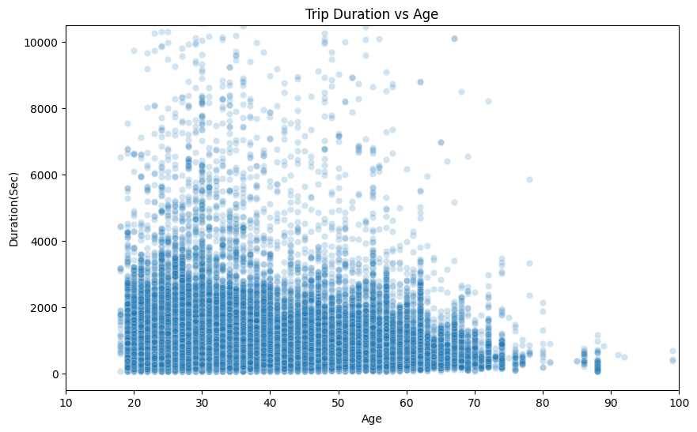

### **Gender vs Trip Duration**

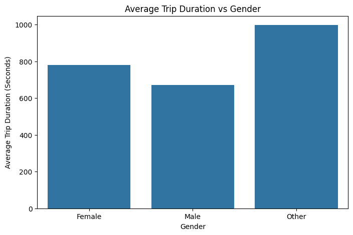

### **Age vs Trip Duration by User Type**

Key Insight: Customers generally shows the longer duration compare to the subscriber, and most rider are concerntrated at lower duration regardless of age

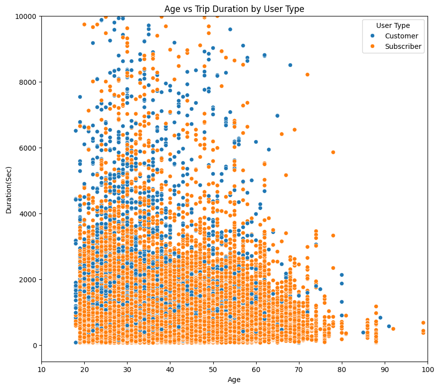

### **Gender vs Trip Duration by User Age**

Key Insight: Most riders are concerntrated at shorter durations irrespective of their gender and age groups, and male riders contribute highest number of trip throughout the age distributions

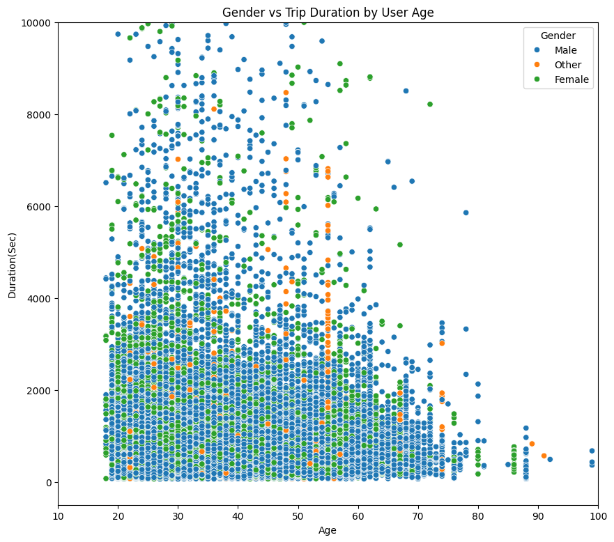